# 1 Maximum Likelihood

### 1.1 Maximum Likelihood

Find the parameters of a model that best fit the data.

Forms the foundation of Bayesian inference

### 1.2 Distributions of Discrete Variables

Random variables (the observed data)

- Discrete
- Are integer values

Example:

- Binomial
- Multinomial
- Poisson
- Negative binomial

### 1.3 Distributions of Continuous Variables

Random variables are continuous

Example:

- Gaussian (normal)
- Log normal
- Gamma
- Beta

### 1.4 PMF of Poisson

Probability mass function (PMF) is a function that gives the probability that a discrete random variable is exactly equal to some value

P(Yi=k| rate : parameter=r)=$\frac{e^{-r}r^k}{k!}$

In one unit of time we predict that Y<sub>i</sub> = k

P(Yi=k| rate : parameter=r)=$\frac{e^{-r}r^k}{k!}$

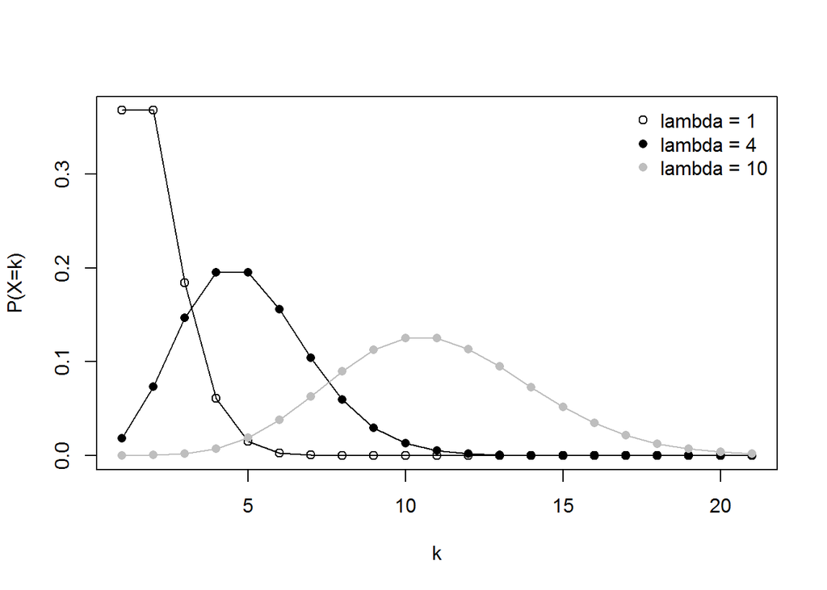

*Figure 1.4.1*

### 1.5 The Poisson Distribution

Description

- Density, distrubution function, quantile function and random generation for the Poisson distribution with parameter lambda.

Usage

- dpois (x, lambda, log = FALSE)
- ppois (q, lambda, lower.tail = TRUE, log.p = FALSE)
- qpois (p, lambda, lower.tail = TRUE, log.p = FALSE)
- rpois (n, lambda)

Arguments

- x - Vector of (non-negative integer) quantiles
- q - Vector of quantiles
- p - vector of probabilities
- n - number of random values to return
- lambda - vector of (non-negative) means
- log, log.p - logical; if TRUE, probabilities p are given as log(p)
- lower.tail - logical; if TRUE, (default), probabilities are P[X $\leq$ x], otherwise, P[X > x]

### 1.6 Likelihood

P(Y<sub>i</sub> | p)

Probability distribution of observing data Yi, given a particular parameter value, p

Subscript on Y indicates that there are many possible outcomes but only one possible parameter.

P(Yi=k| rate : parameter=r)=$\frac{e^{-r}r^k}{k!}$

This expression is the probability of “data” given the hypothesis.

- Data are k events in one unit time
- Hypothesis is that the rate parameter is r

After collection of the data, the data are known.

Alternative hypotheses are different values of r.

Given the data, how likely are the possible hypotheses?

Introduce symbol: “L” likelihood

L(data | hypothesis), L(Y | p<sub>m</sub>)

Shift in thinking - m alternative parameters.

One set of data

Difference in likelihood and probability:

- Probability: the hypothesis is known, data are unknown
- Likelihood: data are known, hypothesis is not known

### 1.7 Likelihood in Practice

Generate data

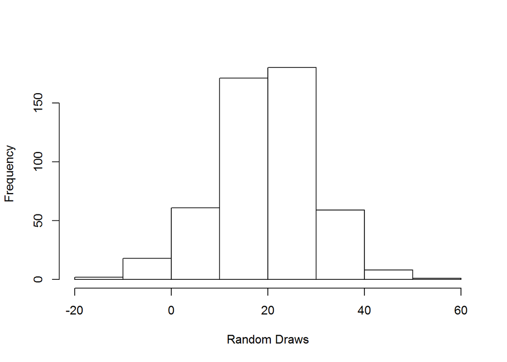

*Figure 1.7.1*

Determine range of parameter values that are alternative hypotheses

- best.guess.mu <- seq(15,25,by = 0.1)
- best.guess.sig <- 5

Determine the probability that the data came from a distribution with a given parameter value

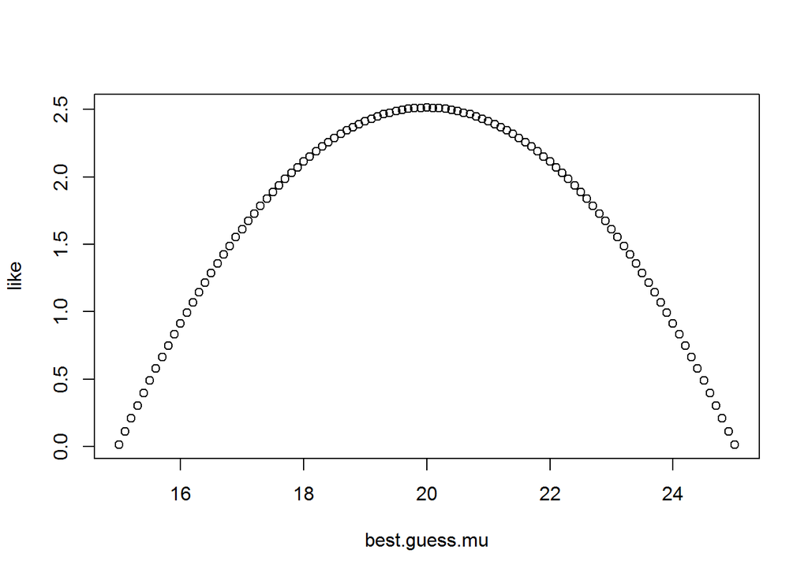

*Figure 1.7.2*